# p8105_hw3_jf3286.Rmd

Jingyu Fu

2019/10/13

## Prob 1

load data from website

```r
library(p8105.datasets)
data("instacart")
```

Description:

This data has 15 columns and1384617rows. It contains numeric columns and character columns. Overall, this data contains inforation about order ID, product ID, customer ID, aisle name, the number of products, the number of order, etc. The key variables are those including ID information, beucase these variables are unique to each order or user. From this data we can tell what has a certain customer purchased. For example, we can tell thet user ID 112108 purchased Bulgarian Yogurt, Organic 4% Milk Fat Whole Milk Cottage Cheese, Organic Celery Hearts, and other 5 types of product. We can also tell how many times a certain customer has ordered a product. For example, user ID 112108 ordered Bulgarian Yogurt twice, becuase it is shown in caolumn of reordered that it has been reordered once.

Number of aisle

```r
  instacart%>%
  group_by (aisle) %>%
  summarize (
    n_aisle = n()
    )
```

```
## # A tibble: 134 x 2
##    aisle                  n_aisle
##    <chr>                    <int>
##  1 air fresheners candles    1067
##  2 asian foods               7007
##  3 baby accessories           306
##  4 baby bath body care        328
##  5 baby food formula        13198
##  6 bakery desserts           1501
##  7 baking ingredients       13088
##  8 baking supplies decor     1094
##  9 beauty                     287
## 10 beers coolers             1839
## # ... with 124 more rows
```

```r
 instacart_n_items = instacart %>%
  group_by(aisle) %>%
  summarize (
    n_items = sum(add_to_cart_order)
  )

  instacart_n_items %>%  mutate(
    rank_items = rank(n_items)
  ) %>%
  filter (
    rank_items == 1
  )
```

```
## # A tibble: 1 x 3
##   aisle                      n_items rank_items
##   <chr>                        <int>      <dbl>
## 1 specialty wines champagnes    2491          1
```

Making plots,limiting to aisles with more than 10000 items, arranging aisles, and organizing plots

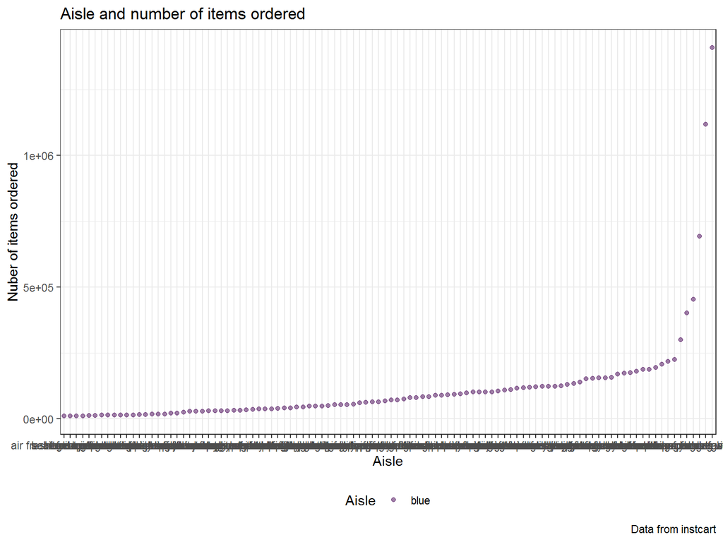

```r
instacart_n_items %>%
  filter(
    n_items >= 10000
    ) %>%
   mutate(
    aisle = factor(aisle),
    aisle = fct_reorder(aisle, n_items)
  ) %>%
  ggplot(aes (x = aisle, y = n_items, color ="blue")) +
  geom_point(alpha = .5) +
  labs(
    title = "Aisle and number of items ordered",
    x = "Aisle",
    y = "Nuber of items ordered",
    caption = "Data from instcart"
  ) +
  theme_bw()+
  theme(legend.position = "bottom")+
  viridis::scale_color_viridis(
    name = "Aisle",
    discrete = TRUE
  )
```

Comments

The plots look like a function graph. The number of items ordered from each ailse increased steadily at first but then there’s a sudden severe increase. For most of the aisles, each has 10110 ~ (5e^5)/2 items ordered, but for several others, there are a lot more.

Making tables showing the three most popular items in each of the aisles

```r
instacart %>%
  group_by(aisle) %>%
  mutate(
    add_to_cart_order = desc(add_to_cart_order),
    rank_product = min_rank(add_to_cart_order)
  ) %>%
  filter(
    rank_product == 1,2,3
  ) %>%
  select(aisle, rank_product, product_name, add_to_cart_order) %>%
   knitr::kable()
```

| aisle | rank_product | product_name | add_to_cart_order |
| --- | --- | --- | --- |
| feminine care | 1 | Ultimate Flora Vaginal Support Probiotic Supplement Vegetable Capsules | -65 |
| dog food care | 1 | Sausage Cuts Real Beef Treats | -66 |
| energy granola bars | 1 | Mighty Bar Beef with Uncured Bacon & Apple Protein Bar | -69 |
| bread | 1 | Sourdough Bread | -70 |
| soft drinks | 1 | Diet 12 Oz Ginger Ale | -60 |
| specialty cheeses | 1 | Fresh Mozzarella Snacking Cheese | -64 |
| frozen breads doughs | 1 | Gluten Free Whole Grain Bread | -52 |
| body lotions soap | 1 | Hydro Body Sponge With Hand Strap | -57 |
| facial care | 1 | Deep Action Cream Cleanser | -52 |
| tofu meat alternatives | 1 | Meatless Vegan Hot Dogs | -55 |
| other | 1 | Premium Lubricant Condoms ENZ | -67 |
| hair care | 1 | Color Me Happy Colorsafe Shampoo | -68 |
| laundry | 1 | Regular Concentrated Bleach | -69 |
| dish detergents | 1 | Dishwasher Detergent | -70 |
| food storage | 1 | Aluminum Foil | -71 |
| spirits | 1 | Single Malt Scotch Whisky | -67 |
| beers coolers | 1 | Dark Belgian Beer | -75 |
| missing | 1 | YoKids Organic Low Fat Strawberry Banana Yogurt | -57 |
| soap | 1 | Safe & Natural Tropical Coconut Twist Liquid Soap For Kids | -67 |
| bakery desserts | 1 | Chocolate Cupcake | -69 |
| grains rice dried goods | 1 | All Natural Organic Green Lentils | -70 |
| candy chocolate | 1 | Pretzel Chocolate Organic | -72 |
| ice cream ice | 1 | Chocolate Ice Cream | -73 |
| hot dogs bacon sausage | 1 | Organic Sunday Bacon | -74 |
| oils vinegars | 1 | Extra Virgin Olive Oil | -75 |
| canned meat seafood | 1 | Wild Albacore Tuna No Salt Added | -76 |
| muscles joints pain relief | 1 | Premium Epsom Salt | -47 |
| protein meal replacements | 1 | Alkalize Detox Green Super Food Single Packet | -64 |
| soup broth bouillon | 1 | Organic Beef Broth | -58 |
| oral hygiene | 1 | Pronamel Gentle Whitening Toothpaste | -59 |

[output cut: 115 more lines]

Each aisle has its own most popular items. For example, the most popular item in aisle dog food care is sausage cuts real beef treats. The order number of the most popular items in each aisle is around 60 to 80.

Making table showing the mean hour of the day at which Pink Lady Apples and Coffee Ice Cream are ordered on each day of the week.

```r
instacart_2products = instacart %>%
  group_by(product_name,order_dow) %>%
  filter(
    product_name %in%  c("Pink Lady Apples","Coffee Ice Cream")
    )  %>%
  summarize(
    mean_hour = mean(order_hour_of_day)

  ) %>%
  pivot_wider (
    names_from = order_dow,
    values_from = mean_hour
  )

instacart_2products
```

```
## # A tibble: 2 x 8
## # Groups:   product_name [2]
##   product_name       `0`   `1`   `2`   `3`   `4`   `5`   `6`
##   <chr>            <dbl> <dbl> <dbl> <dbl> <dbl> <dbl> <dbl>
## 1 Coffee Ice Cream  13.8  14.3  15.4  15.3  15.2  12.3  13.8
## 2 Pink Lady Apples  13.4  11.4  11.7  14.2  11.6  12.8  11.9
```

Comments Coffee Ice Cream has its highest mean order hour of the day on order_dow 2(which is Monday), while Pink Lady Apples has its highest mean order hour of the day on order_dow 3 (which is Tuesday).

## Problem 2

Load data from a package, and do some data cleaning:

```r
library(p8105.datasets)
data("brfss_smart2010")

brfss_smart2010 = brfss_smart2010 %>%
janitor::clean_names() %>%
  rename (
    state = locationabbr ,
    county = locationdesc
  ) %>%
  filter(
    topic == "Overall Health",
   response %in% c("Poor", "Fair", "Good", "Very good", "Excellent")
           ) %>%
  mutate (
    response = factor(response),
    response = fct_relevel (response, "Poor", "Fair", "Good", "Very good", "Excellent")
  )
brfss_smart2010
```

```
## # A tibble: 10,625 x 23
##     year state county class topic question response sample_size data_value
##    <int> <chr> <chr>  <chr> <chr> <chr>    <fct>          <int>      <dbl>
##  1  2010 AL    AL - ~ Heal~ Over~ How is ~ Excelle~          94       18.9
##  2  2010 AL    AL - ~ Heal~ Over~ How is ~ Very go~         148       30
##  3  2010 AL    AL - ~ Heal~ Over~ How is ~ Good             208       33.1
##  4  2010 AL    AL - ~ Heal~ Over~ How is ~ Fair             107       12.5
##  5  2010 AL    AL - ~ Heal~ Over~ How is ~ Poor              45        5.5
##  6  2010 AL    AL - ~ Heal~ Over~ How is ~ Excelle~          91       15.6
##  7  2010 AL    AL - ~ Heal~ Over~ How is ~ Very go~         177       31.3
##  8  2010 AL    AL - ~ Heal~ Over~ How is ~ Good             224       31.2
##  9  2010 AL    AL - ~ Heal~ Over~ How is ~ Fair             120       15.5
## 10  2010 AL    AL - ~ Heal~ Over~ How is ~ Poor              66        6.4
## # ... with 10,615 more rows, and 14 more variables:
## #   confidence_limit_low <dbl>, confidence_limit_high <dbl>,
## #   display_order <int>, data_value_unit <chr>, data_value_type <chr>,
## #   data_value_footnote_symbol <chr>, data_value_footnote <chr>,
## #   data_source <chr>, class_id <chr>, topic_id <chr>, location_id <chr>,
## #   question_id <chr>, respid <chr>, geo_location <chr>
```

In 2002 and 2010, finding the states that were observed at 7 or more locations.

```r
brfss_smart2010 %>%
  group_by(state) %>%
  filter(year == 2002) %>%
  summarize (
    n_location = n_distinct(county)
  ) %>%
    filter(n_location >= 7)
```

```
## # A tibble: 6 x 2
##   state n_location
##   <chr>      <int>
## 1 CT             7
## 2 FL             7
## 3 MA             8
## 4 NC             7
## 5 NJ             8
## 6 PA            10
```

```r
brfss_smart2010 %>%
  group_by(state) %>%
  filter(year == 2010) %>%
  summarize (
    n_location = n_distinct(county)
  ) %>%
    filter(n_location >= 7)
```

```
## # A tibble: 14 x 2
##    state n_location
##    <chr>      <int>
##  1 CA            12
##  2 CO             7
##  3 FL            41
##  4 MA             9
##  5 MD            12
##  6 NC            12
##  7 NE            10
##  8 NJ            19
##  9 NY             9
## 10 OH             8
## 11 PA             7
## 12 SC             7
## 13 TX            16
## 14 WA            10
```

Comments In 2002, there are 6 states that were observed at 7 or more locations, while in 2010, there were 14. States including FL, MA, NC, NJ, PA were both observed in 2002 and 2010.

Construct a dataset that is limited to Excellent responses, and contains, year, state, and a Make a “spaghetti” plot of this average value over time within a state.

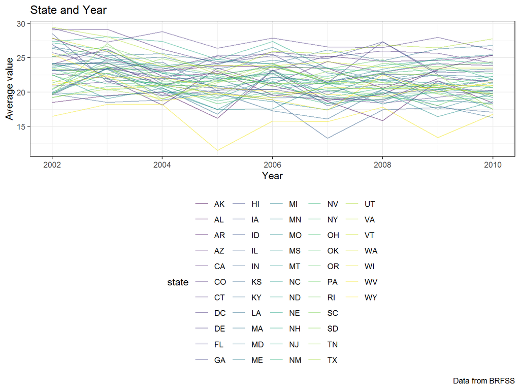

```r
dataset_prob2 = brfss_smart2010 %>%
  group_by(state,year) %>%
  filter (response == "Excellent") %>%
  mutate (ave_data_value = mean (data_value)) %>%
  select (year, state, ave_data_value)

 dataset_prob2 %>%
  ggplot()+
  geom_line( aes (x = year, y = ave_data_value, color = state),alpha = .5)+
   labs (
     title = "State and Year",
     x = "Year",
     y = "Average value",
     caption = "Data from BRFSS"
   )+
   theme_bw()+
   theme(legend.position = "bottom") +
   viridis::scale_color_viridis(
    name = "state",
    discrete = TRUE
  )
```

Comments

For most those with a “Excellent” response, the average data value changes severely over time. For very few of them, the average value stays somewhere between 20 and 25, and most of them are between 15 and 30.

Make a two-panel plot showing, for the years 2006, and 2010, distribution of data_value for responses (“Poor” to “Excellent”) among locations in NY State.

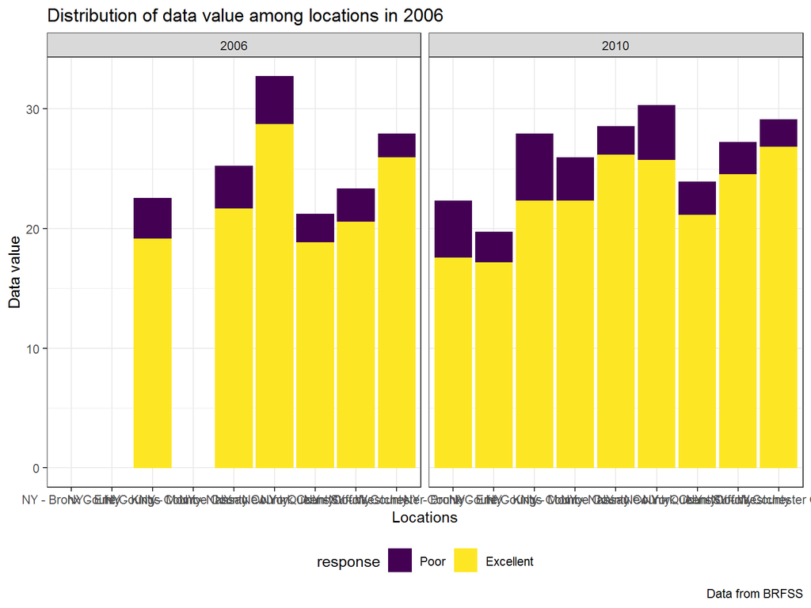

```r
plot_of_distribution = brfss_smart2010 %>%
  group_by(response,year) %>%
  filter(state == "NY" & year %in% c("2006","2010")  & response %in% c("Poor","Excellent")) %>%
  ggplot(aes(x = county, y = data_value, color = response))+
  geom_col(aes(fill = response))+
  labs (
     title = "Distribution of data value among locations in 2006",
     x = "Locations",
     y = "Data value",
     caption = "Data from BRFSS"
   )+
   theme_bw()+
   theme(legend.position = "bottom")+
  facet_grid (~ year)+
  viridis::scale_color_viridis(
    name = "response",
    discrete = TRUE)

plot_of_distribution
```

## Problem 3

Load, tidy, and otherwise wrangle the data.

```r
accel_data = read_csv(file = "./accel_data.csv") %>%
  janitor::clean_names() %>%
  mutate(
    day_of_week = case_when(
      day == "Monday" ~ "Weekday",
      day == "Tuesday" ~ "Weekday",
      day == "Wednesday" ~ "Weekday",
      day == "Thursday" ~ "Weekday",
      day == "Friday" ~ "Weekday",
      day == "Saturday" ~ "Weekend",
      day == "Sunday" ~ "Weekend",
      TRUE ~ ""
      )
           ) %>%
  select(week, day_id, day, day_of_week,everything())
```

Aggregate accross minutes to create a total activity variable for each day, and create a table showing these totals.

```r
accel_data_tra = accel_data %>%
  group_by (day_id) %>%
  pivot_longer(
    activity_1:activity_64,
    names_to = "activity_number",
    names_prefix = "activity_",
    values_to = "activity_counts"
  ) %>%
  mutate(
    activity_total = sum(activity_counts)
  ) %>%
  select (week, day_id, day, day_of_week, activity_total)

 accel_data_tra %>%
  knitr::kable()
```

[output not shown]

[output cut: 2211 more lines]

There is a general decreasing trend from Monday to Wednesday, but a sudden increase on Thursday, and then a general decreasing trend form Thursday to Sunday.

Make a single-panel plot that shows the 24-hour activity time courses for each day and use color to indicate day of the week.

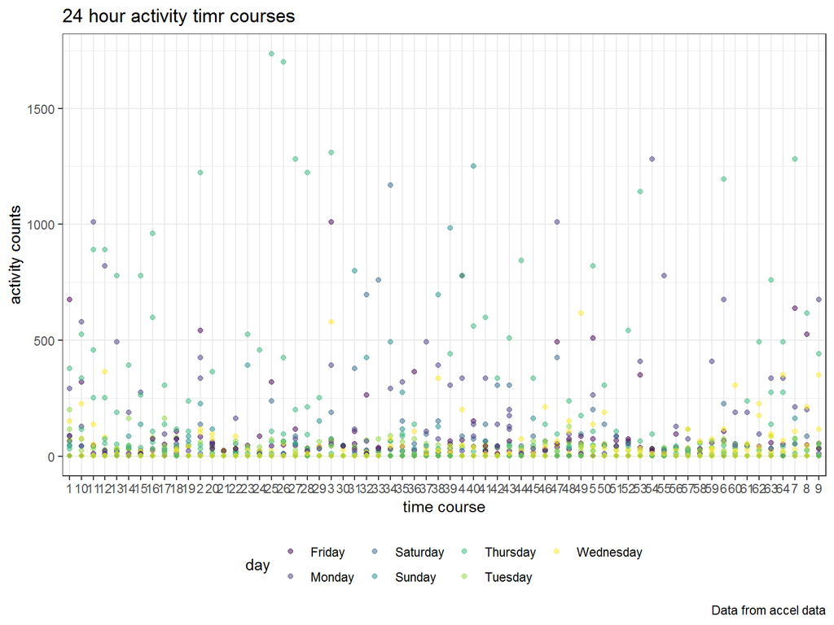

```r
accel_data %>%
  pivot_longer(
    activity_1:activity_64,
    names_to = "activity_number",
    names_prefix = "activity_",
    values_to = "activity_counts"
  ) %>%
  ggplot(aes(x = activity_number, y = activity_counts, color = day)) +
  geom_point(alpha = .5)+
  labs(
    title = "24 hour activity timr courses",
    x = "time course",
    y = "activity counts",
    caption = "Data from accel data"

  )+
  theme_bw()+
  theme(legend.position = "bottom")
```